# Ejemplo_Elisa

Elisa Rovai

4/11/2021

```r
source("teoriadecision_funciones_incertidumbre.R")
```

Funciòn de grupo por el criterio de Hurwicz:

```r
alfas = function(tablaX, precisionAlfa=0.05, favorable=TRUE){
  X = tablaX;
  Altmin = apply(X,MARGIN=1,min);
  Altmax = apply(X,MARGIN=1,max);
  valfa = seq(from=0,to=1,by=precisionAlfa);
  vHurwicz = rep(0,length(valfa));
  alternativa = rep(0,length(valfa));
  Alt_vHurwicz = rep(0,length(valfa));
  for (i in 1:length(valfa)) {
    alfab = valfa[i];
    if (favorable) {
      vAltH = alfab * Altmax + (1-alfab) * Altmin;
      vHurwicz[i] = max(vAltH)
      alternativa[i]=which.max(vAltH) #que alternativa lo cumple
    } else {
      vAltH = alfab * Altmin + (1-alfab) * Altmax;
      vHurwicz[i] = min(vAltH)
      alternativa[i]=which.min(vAltH) #que alternativa lo cumple
    }
  }

  altsinrep=unique(alternativa) #me quedo con las diferentes alternativas
                                #(quitando las repeticiones)
  alfasb = (which(!duplicated(alternativa)))*precisionAlfa - precisionAlfa
  #posiciones de cuándo aparecen las nuevas alternativas en el intervalo [0,1] (alfas)
  alfas=alfasb[-1] #quitamos la primera que siempre será 0)

  #salida que se nos pide:
  return(

    if (length(alfas)==1) {
      cat ("La mejor alternativa es",altsinrep[1],"para alfa perteneciente a [ 0 ,",
           alfas[1],"] y la mejor alternativa es",altsinrep[2],
           "para alfa perteneciente a [",alfas[1],", 1 ]")
    } else {
      if (length(alfas)==2) {
        cat ("La mejor alternativa es",altsinrep[1],"para alfa perteneciente a [ 0 ,",
             alfas[1],"], la mejor alternativa es",altsinrep[2],
             "para alfa perteneciente a [",alfas[1],",",alfas[2],
             "] y la mejor alternativa es", altsinrep[3], "si alfa pertenece a [",
             alfas[2],", 1 ]")
      } else {
        cat ("La mejor alternativa es",altsinrep[1],"para alfa perteneciente a [ 0 ,",
             alfas[1],"], ")
        for (i in 1:(length(alfas)-1)) {
          cat ("la mejor alternativa es",altsinrep[i],"para alfa perteneciente a [",
               alfas[i],",",alfas[i+1],"] ")
        }
        cat ("y la mejor alternativa es", altsinrep[length(altsinrep)], "si alfa pertenece a [",
             alfas[length(alfas)],", 1 ]")
      }

    })
}
```

Enunciado: María tiene que elegir un piso donde vivir por un año. Su decisión depiende da la posición del piso y da los costes que va a tener en base a la posición. María puede elegir si vivir: En centro [0-10]km dal centro + 10 km

Si elige el más lejos tiene que pagar 350 euros de alquilar, 20 euros de facturas y 70 euros de transporte al mes

¿Cuál es la mejor decisión para que se gaste lo menos posible?

Definiciòn partes del problema:

Planteamiento: -Un decisor -Modelo no favorable

Alternativas: 1 = “Centro” 2 = “[0-10]km desde el centro” 3 = “+10 km desde el centro”

Estados de la naturaleza: E1: alquilar E2: facturas E3: transporte

soluciòn:

```r
tE = matrix(c(500,430,350,12,9,20,0,20,70),nrow = 3)
rownames(tE) <- c("Centro", "[0,10]km desde centro", "+10 km desde centro")
colnames(tE) <- c("Alquilar", "Facturas", "Transporte")
tE
```

```
##                       Alquilar Facturas Transporte
## Centro                     500       12          0
## [0,10]km desde centro      430        9         20
## +10 km desde centro        350       20         70
```

```r
criterio.Todos(tE, alfa=0.3,favorable = FALSE)
```

```
##                       Alquilar Facturas Transporte                Wald
## Centro                     500       12          0                 500
## [0,10]km desde centro      430        9         20                 430
## +10 km desde centro        350       20         70                 350
## iAlt.Opt (Desfav.)          --       --         -- +10 km desde centro
##                       Optimista             Hurwicz              Savage
## Centro                        0               350.0                 150
## [0,10]km desde centro         9               303.7                  80
## +10 km desde centro          20               251.0                  70
## iAlt.Opt (Desfav.)       Centro +10 km desde centro +10 km desde centro
##                                   Laplace         Punto Ideal
## Centro                              170.7              150.03
## [0,10]km desde centro               153.0               82.46
## +10 km desde centro                 146.7               70.86
## iAlt.Opt (Desfav.)    +10 km desde centro +10 km desde centro
```

Para el criterio optimista la meor alternativa es “el centro” para los otro “+ 10km desde el centro”

Para el criterio de Hurwitc con un nivel de alfa diferente:

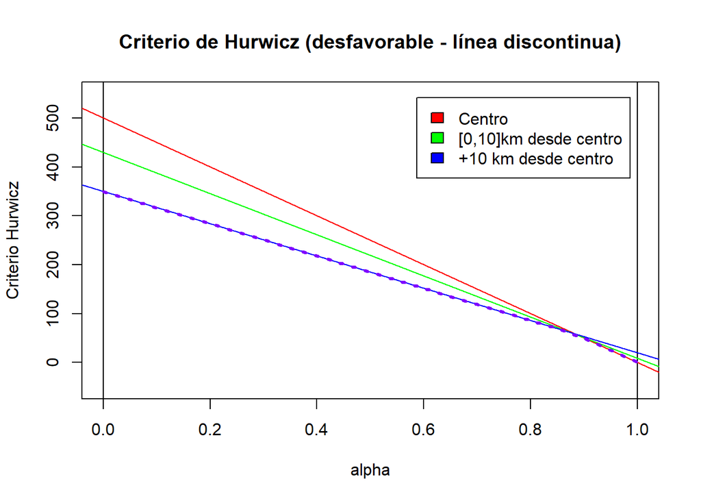

```r
dibuja.criterio.Hurwicz(tE,favorable=FALSE)
```

```r
alfas(tE,precisionAlfa = 0.02,favorable = FALSE)
```

```
## La mejor alternativa es 3 para alfa perteneciente a [ 0 , 0.88 ], la mejor alternativa es 2 para alfa perteneciente a [ 0.88 , 0.9 ] y la mejor alternativa es 1 si alfa pertenece a [ 0.9 , 1 ]
```

```r
alfas(tE,precisionAlfa = 0.07,favorable = FALSE)
```

```
## La mejor alternativa es 3 para alfa perteneciente a [ 0 , 0.91 ] y la mejor alternativa es 1 para alfa perteneciente a [ 0.91 , 1 ]
```